# Patterns from bullet chess games

## Introducing the observations

This visual data story is based on logged bullet chess games. Each row records one game observation, including the result, whether I played White or Black, how the game ended, the opponent rating, the timestamp, and how much time I had left. The main question I wanted to explore was whether the fast time control created visible patterns in results, endings, and opponent strength.

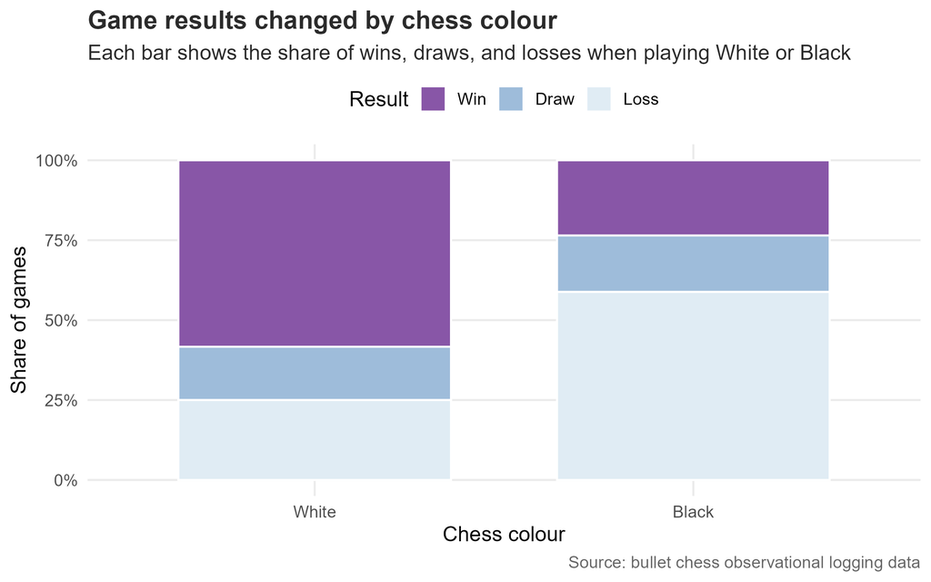

A stacked bar chart comparing bullet chess results when playing White and Black, showing the share of wins, draws, and losses for each colour.

## Colour and result

The first comparison looks at whether results changed depending on the colour I played. In chess, White moves first, so it is useful to compare White and Black games instead of only counting wins and losses overall. This plot helps show whether one colour led to a stronger result pattern in the logged games.

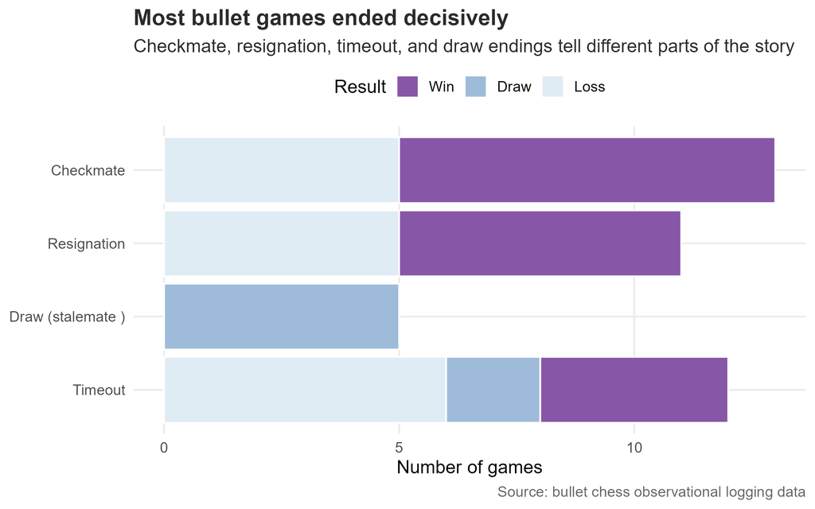

A horizontal stacked bar chart showing how many bullet chess games ended by checkmate, resignation, timeout, or draw, split by game result.

## How games finished

Bullet games can end in several different ways, and the ending type gives more detail than the result alone. Checkmate and resignation suggest decisive positions, while timeout shows the pressure of the clock. Comparing endings makes the story more specific because it shows not just whether the game was won or lost, but how the fast game reached that outcome.

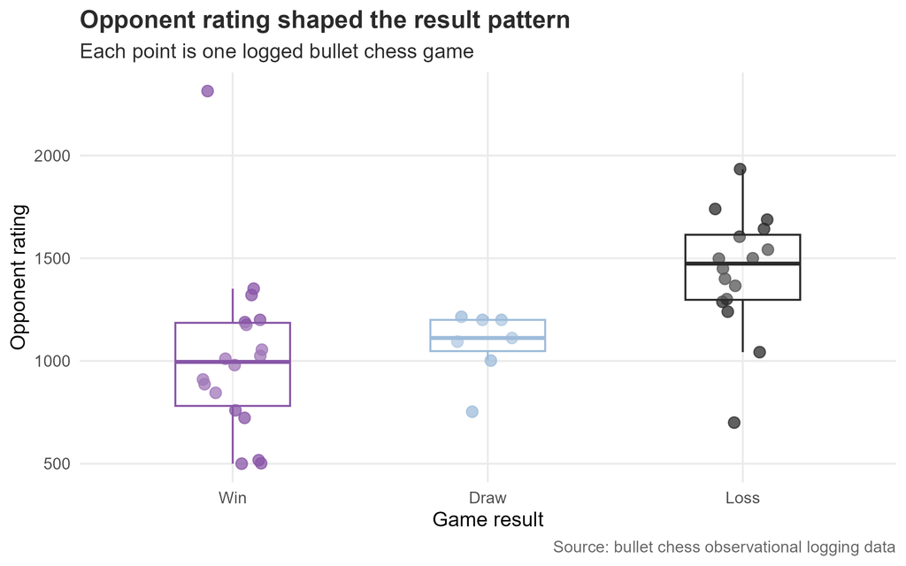

A jitter and boxplot chart comparing opponent rating across wins, draws, and losses in the logged bullet chess games.

## Opponent strength

The opponent rating plot adds another layer to the story. Instead of treating every result as equal, it shows the rating range of opponents linked to wins, draws, and losses. This helps show whether losses tended to happen against stronger opponents, or whether the results were more mixed across rating levels.

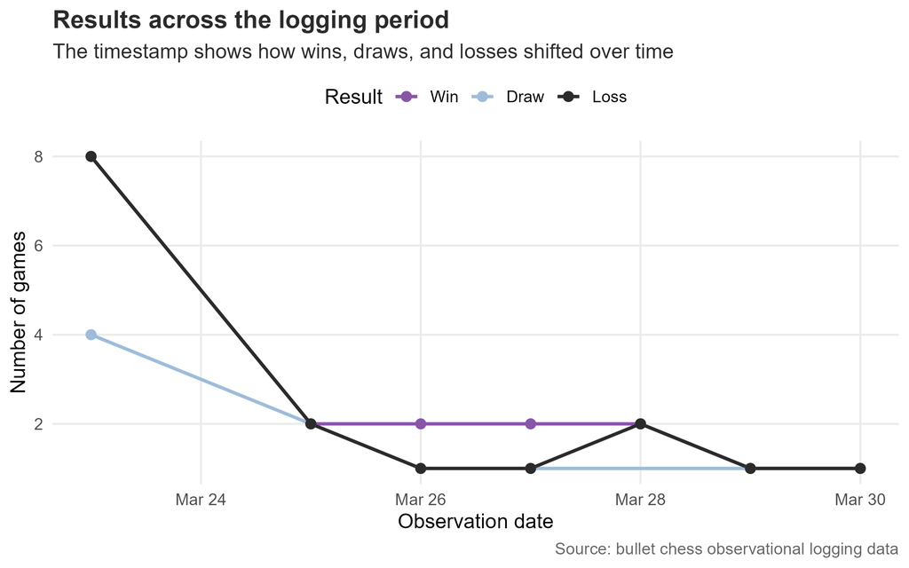

A line chart using timestamps to show how wins, draws, and losses changed across the logged dates.

## What this suggests

Overall, the logged bullet chess games show that results are shaped by several connected factors: colour, ending type, opponent rating, and time. The story is not only about the final result. It is also about the different ways short chess games unfold under time pressure, especially when games end by timeout, resignation, or checkmate.